# Machine Downtime Analysis and Operational Performance Evaluation

## Student Information

**Name:** Ozan Berk Aydin

**Student ID:** GH1046991

**Module:** M504 – AI and Applications

## Dataset Source

https://www.kaggle.com/datasets/srinivasanusuri/optimization-of-machine-downtime

## GitHub Repository

https://github.com/ozanberkaydin/M504_Machine_Downtime_EDA

## Objective

The objective of this project is to analyze machine downtime patterns, identify operational issues, evaluate machine performance, and provide recommendations for improving manufacturing efficiency.

## 1. Business Context

Manufacturing companies depend on reliable machine performance to maintain productivity, product quality, and delivery targets. Unexpected machine downtime can disrupt production schedules, increase maintenance costs, and reduce overall equipment effectiveness.

This project analyses operational data collected from CNC machining equipment. The dataset contains machine identifiers, assembly line information, sensor measurements, and machine failure records. Key operational variables include hydraulic pressure, spindle speed, temperature, vibration, torque, and cutting force.

The objective of this analysis is to identify patterns associated with machine failures, evaluate machine performance, and generate data-driven recommendations for preventive maintenance. The findings can help maintenance teams reduce downtime, improve equipment reliability, and support operational decision-making.

## 2. Dataset Description

The dataset was obtained from Kaggle and contains CNC machine operating data with downtime status.

It has 2,500 observations and 16 variables covering machine ID, assembly line, date, sensor readings and downtime outcome.

Key fields include hydraulic, coolant and air pressure; coolant, hydraulic oil and spindle bearing temperature; spindle and tool vibration; spindle speed; voltage; torque; cutting force; and Downtime, which records Machine_Failure or No_Machine_Failure.

Because the dataset combines numerical sensor measures with categorical machine and line information, it is suitable for exploratory analysis of operating patterns linked to downtime.

## 3. Import Libraries

```python
import pandas as pd
import matplotlib.pyplot as plt
import seaborn as sns
```

## 4. Load Dataset

```python
df = pd.read_csv("data/machine_downtime.csv")
df.head()
```

|  | Date | Machine_ID | Assembly_Line_No | Hydraulic_Pressure(bar) | Coolant_Pressure(bar) | Air_System_Pressure(bar) | Coolant_Temperature | Hydraulic_Oil_Temperature(?C) | Spindle_Bearing_Temperature(?C) | Spindle_Vibration(?m) | Tool_Vibration(?m) | Spindle_Speed(RPM) | Voltage(volts) | Torque(Nm) | Cutting(kN) | Downtime |
| --- | --- | --- | --- | --- | --- | --- | --- | --- | --- | --- | --- | --- | --- | --- | --- | --- |
| 0 | 31-12-2021 | Makino-L1-Unit1-2013 | Shopfloor-L1 | 71.04 | 6.933725 | 6.284965 | 25.6 | 46.0 | 33.4 | 1.291 | 26.492 | 25892.0 | 335.0 | 24.055326 | 3.58 | Machine_Failure |
| 1 | 31-12-2021 | Makino-L1-Unit1-2013 | Shopfloor-L1 | 125.33 | 4.936892 | 6.196733 | 35.3 | 47.4 | 34.6 | 1.382 | 25.274 | 19856.0 | 368.0 | 14.202890 | 2.68 | Machine_Failure |
| 2 | 31-12-2021 | Makino-L3-Unit1-2015 | Shopfloor-L3 | 71.12 | 6.839413 | 6.655448 | 13.1 | 40.7 | 33.0 | 1.319 | 30.608 | 19851.0 | 325.0 | 24.049267 | 3.55 | Machine_Failure |
| 3 | 31-05-2022 | Makino-L2-Unit1-2015 | Shopfloor-L2 | 139.34 | 4.574382 | 6.560394 | 24.4 | 44.2 | 40.6 | 0.618 | 30.791 | 18461.0 | 360.0 | 25.860029 | 3.55 | Machine_Failure |
| 4 | 31-03-2022 | Makino-L1-Unit1-2013 | Shopfloor-L1 | 60.51 | 6.893182 | 6.141238 | 4.1 | 47.3 | 31.4 | 0.983 | 25.516 | 26526.0 | 354.0 | 25.515874 | 3.55 | Machine_Failure |

```python
df.shape
```

```
(2500, 16)
```

```python
df.info()
```

```
<class 'pandas.DataFrame'>
RangeIndex: 2500 entries, 0 to 2499
Data columns (total 16 columns):
 #   Column                           Non-Null Count  Dtype
---  ------                           --------------  -----
 0   Date                             2500 non-null   str
 1   Machine_ID                       2500 non-null   str
 2   Assembly_Line_No                 2500 non-null   str
 3   Hydraulic_Pressure(bar)          2490 non-null   float64
 4   Coolant_Pressure(bar)            2481 non-null   float64
 5   Air_System_Pressure(bar)         2483 non-null   float64
 6   Coolant_Temperature              2488 non-null   float64
 7   Hydraulic_Oil_Temperature(?C)    2484 non-null   float64
 8   Spindle_Bearing_Temperature(?C)  2493 non-null   float64
 9   Spindle_Vibration(?m)            2489 non-null   float64
 10  Tool_Vibration(?m)               2489 non-null   float64
 11  Spindle_Speed(RPM)               2494 non-null   float64
 12  Voltage(volts)                   2494 non-null   float64
 13  Torque(Nm)                       2479 non-null   float64
 14  Cutting(kN)                      2493 non-null   float64
 15  Downtime                         2500 non-null   str
dtypes: float64(12), str(4)
memory usage: 312.6 KB
```

```python
df.describe()
```

|  | Hydraulic_Pressure(bar) | Coolant_Pressure(bar) | Air_System_Pressure(bar) | Coolant_Temperature | Hydraulic_Oil_Temperature(?C) | Spindle_Bearing_Temperature(?C) | Spindle_Vibration(?m) | Tool_Vibration(?m) | Spindle_Speed(RPM) | Voltage(volts) | Torque(Nm) | Cutting(kN) |
| --- | --- | --- | --- | --- | --- | --- | --- | --- | --- | --- | --- | --- |
| count | 2490.000000 | 2481.000000 | 2483.000000 | 2488.000000 | 2484.000000 | 2493.000000 | 2489.000000 | 2489.000000 | 2494.000000 | 2494.000000 | 2479.000000 | 2493.000000 |
| mean | 101.409084 | 4.947058 | 6.499275 | 18.559887 | 47.618317 | 35.063698 | 1.009334 | 25.411975 | 20274.792302 | 348.996792 | 25.234968 | 2.782551 |
| std | 30.289301 | 0.997357 | 0.407279 | 8.554480 | 3.768674 | 3.764823 | 0.342898 | 6.437142 | 3852.660056 | 45.376024 | 6.138564 | 0.616688 |
| min | -14.326454 | 0.325000 | 5.063480 | 4.100000 | 35.200000 | 22.600000 | -0.461000 | 2.161000 | 0.000000 | 202.000000 | 0.000000 | 1.800000 |
| 25% | 76.355000 | 4.462464 | 6.217987 | 10.400000 | 45.100000 | 32.500000 | 0.777000 | 21.089000 | 17919.000000 | 319.000000 | 21.666115 | 2.250000 |
| 50% | 96.763486 | 4.939960 | 6.505191 | 21.200000 | 47.700000 | 35.100000 | 1.008000 | 25.455000 | 20137.500000 | 349.000000 | 24.647736 | 2.780000 |
| 75% | 126.415727 | 5.518401 | 6.780550 | 25.600000 | 50.100000 | 37.600000 | 1.236000 | 29.790000 | 22501.750000 | 380.000000 | 30.514008 | 3.270000 |
| max | 191.000000 | 11.350000 | 7.973992 | 98.200000 | 61.400000 | 49.500000 | 2.000000 | 45.726000 | 27957.000000 | 479.000000 | 55.552400 | 3.930000 |

```python
df["Downtime"].value_counts()
```

```
Downtime
Machine_Failure       1265
No_Machine_Failure    1235
Name: count, dtype: int64
```

## 5. Initial Data Exploration

### Initial Data Exploration Summary

The dataset contains 2,500 observations and 16 variables: 12 numerical operating measures, 3 categorical fields and 1 date field.

The target variable, Downtime, is well balanced with 1,265 machine failure records and 1,235 non-failure records. This supports direct comparison between the two operating states.

Several numerical variables contained missing values, which were handled during preprocessing before the exploratory analysis.

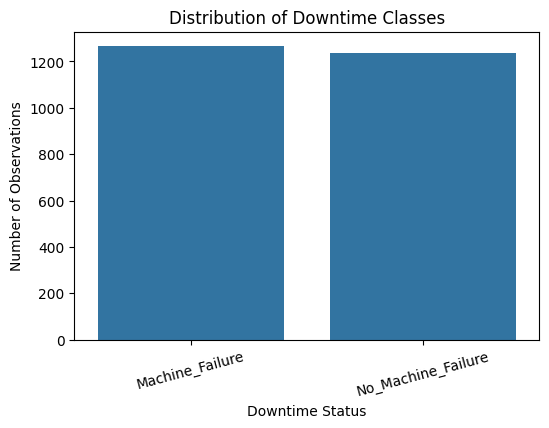

```python
plt.figure(figsize=(6, 4))
sns.countplot(
    data=df,
    x="Downtime"
)

plt.title("Distribution of Downtime Classes")
plt.xlabel("Downtime Status")
plt.ylabel("Number of Observations")
plt.xticks(rotation=15)
plt.show()
```

## 6. Data Cleaning and Preprocessing

```python
df.duplicated().sum()
```

```
np.int64(0)
```

```python
df.isnull().sum()
```

```
Date                                0
Machine_ID                          0
Assembly_Line_No                    0
Hydraulic_Pressure(bar)            10
Coolant_Pressure(bar)              19
Air_System_Pressure(bar)           17
Coolant_Temperature                12
Hydraulic_Oil_Temperature(?C)      16
Spindle_Bearing_Temperature(?C)     7
Spindle_Vibration(?m)              11
Tool_Vibration(?m)                 11
Spindle_Speed(RPM)                  6
Voltage(volts)                      6
Torque(Nm)                         21
Cutting(kN)                         7
Downtime                            0
dtype: int64
```

```python
pressure_columns = [
    "Hydraulic_Pressure(bar)",
    "Coolant_Pressure(bar)",
    "Air_System_Pressure(bar)"
]

negative_pressure_check = df[pressure_columns].lt(0).sum()

negative_pressure_check
```

```
Hydraulic_Pressure(bar)     1
Coolant_Pressure(bar)       0
Air_System_Pressure(bar)    0
dtype: int64
```

```python
df["Date"] = pd.to_datetime(df["Date"], dayfirst=True)

df["Date"].head()
```

```
0   2021-12-31
1   2021-12-31
2   2021-12-31
3   2022-05-31
4   2022-03-31
Name: Date, dtype: datetime64[us]
```

```python
clean_df = df.copy()
clean_df = clean_df.rename(columns={
    "Hydraulic_Oil_Temperature(?C)": "Hydraulic_Oil_Temperature(C)",
    "Spindle_Bearing_Temperature(?C)": "Spindle_Bearing_Temperature(C)",
    "Spindle_Vibration(?m)": "Spindle_Vibration(um)",
    "Tool_Vibration(?m)": "Tool_Vibration(um)"
})

sensor_numeric_columns = clean_df.select_dtypes(include="number").columns

clean_df[sensor_numeric_columns] = clean_df[sensor_numeric_columns].fillna(
    clean_df[sensor_numeric_columns].median()
)
```

```python
clean_df.isnull().sum()
```

```
Date                              0
Machine_ID                        0
Assembly_Line_No                  0
Hydraulic_Pressure(bar)           0
Coolant_Pressure(bar)             0
Air_System_Pressure(bar)          0
Coolant_Temperature               0
Hydraulic_Oil_Temperature(C)      0
Spindle_Bearing_Temperature(C)    0
Spindle_Vibration(um)             0
Tool_Vibration(um)                0
Spindle_Speed(RPM)                0
Voltage(volts)                    0
Torque(Nm)                        0
Cutting(kN)                       0
Downtime                          0
dtype: int64
```

```python
clean_df.duplicated().sum()
```

```
np.int64(0)
```

```python
clean_df.info()
```

```
<class 'pandas.DataFrame'>
RangeIndex: 2500 entries, 0 to 2499
Data columns (total 16 columns):
 #   Column                          Non-Null Count  Dtype
---  ------                          --------------  -----
 0   Date                            2500 non-null   datetime64[us]
 1   Machine_ID                      2500 non-null   str
 2   Assembly_Line_No                2500 non-null   str
 3   Hydraulic_Pressure(bar)         2500 non-null   float64
 4   Coolant_Pressure(bar)           2500 non-null   float64
 5   Air_System_Pressure(bar)        2500 non-null   float64
 6   Coolant_Temperature             2500 non-null   float64
 7   Hydraulic_Oil_Temperature(C)    2500 non-null   float64
 8   Spindle_Bearing_Temperature(C)  2500 non-null   float64
 9   Spindle_Vibration(um)           2500 non-null   float64
 10  Tool_Vibration(um)              2500 non-null   float64
 11  Spindle_Speed(RPM)              2500 non-null   float64
 12  Voltage(volts)                  2500 non-null   float64
 13  Torque(Nm)                      2500 non-null   float64
 14  Cutting(kN)                     2500 non-null   float64
 15  Downtime                        2500 non-null   str
dtypes: datetime64[us](1), float64(12), str(3)
memory usage: 312.6 KB
```

```python
clean_df["Failure_Flag"] = clean_df["Downtime"].map({
    "Machine_Failure": 1,
    "No_Machine_Failure": 0
})

numeric_columns = clean_df.select_dtypes(include="number").columns.drop("Failure_Flag")

clean_df.head()
```

|  | Date | Machine_ID | Assembly_Line_No | Hydraulic_Pressure(bar) | Coolant_Pressure(bar) | Air_System_Pressure(bar) | Coolant_Temperature | Hydraulic_Oil_Temperature(C) | Spindle_Bearing_Temperature(C) | Spindle_Vibration(um) | Tool_Vibration(um) | Spindle_Speed(RPM) | Voltage(volts) | Torque(Nm) | Cutting(kN) | Downtime | Failure_Flag |
| --- | --- | --- | --- | --- | --- | --- | --- | --- | --- | --- | --- | --- | --- | --- | --- | --- | --- |
| 0 | 2021-12-31 | Makino-L1-Unit1-2013 | Shopfloor-L1 | 71.04 | 6.933725 | 6.284965 | 25.6 | 46.0 | 33.4 | 1.291 | 26.492 | 25892.0 | 335.0 | 24.055326 | 3.58 | Machine_Failure | 1 |
| 1 | 2021-12-31 | Makino-L1-Unit1-2013 | Shopfloor-L1 | 125.33 | 4.936892 | 6.196733 | 35.3 | 47.4 | 34.6 | 1.382 | 25.274 | 19856.0 | 368.0 | 14.202890 | 2.68 | Machine_Failure | 1 |
| 2 | 2021-12-31 | Makino-L3-Unit1-2015 | Shopfloor-L3 | 71.12 | 6.839413 | 6.655448 | 13.1 | 40.7 | 33.0 | 1.319 | 30.608 | 19851.0 | 325.0 | 24.049267 | 3.55 | Machine_Failure | 1 |
| 3 | 2022-05-31 | Makino-L2-Unit1-2015 | Shopfloor-L2 | 139.34 | 4.574382 | 6.560394 | 24.4 | 44.2 | 40.6 | 0.618 | 30.791 | 18461.0 | 360.0 | 25.860029 | 3.55 | Machine_Failure | 1 |
| 4 | 2022-03-31 | Makino-L1-Unit1-2013 | Shopfloor-L1 | 60.51 | 6.893182 | 6.141238 | 4.1 | 47.3 | 31.4 | 0.983 | 25.516 | 26526.0 | 354.0 | 25.515874 | 3.55 | Machine_Failure | 1 |

```python
negative_hydraulic_rows = clean_df[
    clean_df["Hydraulic_Pressure(bar)"] < 0
]

hydraulic_pressure_sensitivity = pd.DataFrame({
    "Mean_With_Negative_Value": clean_df.groupby("Downtime")["Hydraulic_Pressure(bar)"].mean(),
    "Mean_Without_Negative_Value": clean_df[
        clean_df["Hydraulic_Pressure(bar)"] >= 0
    ].groupby("Downtime")["Hydraulic_Pressure(bar)"].mean()
})

hydraulic_pressure_sensitivity["Mean_Change"] = (
    hydraulic_pressure_sensitivity["Mean_Without_Negative_Value"]
    - hydraulic_pressure_sensitivity["Mean_With_Negative_Value"]
)

negative_hydraulic_rows[[
    "Date",
    "Machine_ID",
    "Hydraulic_Pressure(bar)",
    "Downtime"
]], hydraulic_pressure_sensitivity
```

```
(           Date            Machine_ID  Hydraulic_Pressure(bar)  \
 2058 2022-02-06  Makino-L3-Unit1-2015               -14.326454

                 Downtime
 2058  No_Machine_Failure  ,
                     Mean_With_Negative_Value  Mean_Without_Negative_Value  \
 Downtime
 Machine_Failure                    84.769987                    84.769987
 No_Machine_Failure                118.414753                   118.522323

                     Mean_Change
 Downtime
 Machine_Failure         0.00000
 No_Machine_Failure      0.10757  )
```

### Data Cleaning Summary

The initial checks found no duplicate records and several missing values across numerical sensor columns. Missing numerical values were replaced with the median of each column so that all 2,500 observations could be retained without giving excessive weight to extreme readings.

The Date column was converted to datetime format, and the failure outcome was mapped to a binary Failure_Flag for comparison, correlation and risk-matrix analysis.

The pressure check found one physically impossible hydraulic pressure value (-14.33 bar) in a non-failure record. It was retained as a sensor anomaly rather than deleted, because the dataset is small enough to report the issue directly and the sensitivity check showed a minimal effect: removing the row changes the non-failure hydraulic-pressure mean by about 0.11 bar and does not change the failure-group mean.

After preprocessing, the cleaned dataset had 0 missing values and 0 duplicate records.

## 7. Exploratory Data Analysis

### Business Question 1: Do vibration levels differ between failure and non-failure conditions?

#### Why is this important?

Vibration is often used as an indicator of machine health. Comparing vibration levels between failure and non-failure conditions helps determine whether vibration monitoring can support preventive maintenance.

```python
clean_df.groupby("Downtime")[["Spindle_Vibration(um)", "Tool_Vibration(um)"]].mean()
```

| Downtime | Spindle_Vibration(um) | Tool_Vibration(um) |
| --- | --- | --- |
| Machine_Failure | 1.003710 | 25.374898 |
| No_Machine_Failure | 1.015083 | 25.450336 |

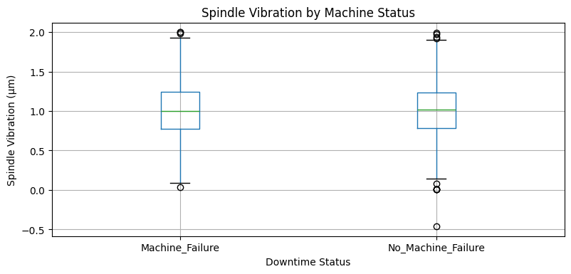

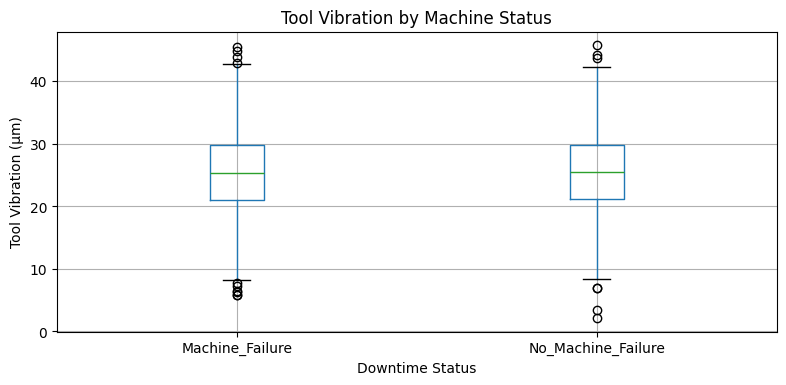

```python
clean_df.boxplot(column="Spindle_Vibration(um)", by="Downtime", figsize=(9, 4))
plt.title("Spindle Vibration by Machine Status")
plt.suptitle("")
plt.ylabel("Spindle Vibration (µm)")
plt.xlabel("Downtime Status")
plt.show()

clean_df.boxplot(column="Tool_Vibration(um)", by="Downtime", figsize=(9, 4))
plt.title("Tool Vibration by Machine Status")
plt.suptitle("")
plt.ylabel("Tool Vibration (µm)")
plt.xlabel("Downtime Status")
plt.show()
```

#### Interpretation

The average spindle vibration was 1.004 um during failures and 1.015 um during normal operation. Tool vibration values were also very similar, at 25.37 um and 25.45 um respectively.

The small differences suggest that vibration is not a reliable standalone indicator of machine failure in this dataset. At this stage, vibration appears weaker than the operating-pressure and speed variables examined in the next business questions, so it should not be used by itself for maintenance decisions.

### Business Question 2: Which machines experience the highest machine failure rate?

#### Why is this important?

Identifying machines with the highest failure rates helps maintenance teams prioritize inspections and reduce unexpected production downtime.

```python
machine_failure_rate = pd.crosstab(
    clean_df["Machine_ID"],
    clean_df["Downtime"],
    normalize="index"
) * 100

machine_failure_rate = machine_failure_rate.sort_values(
    by="Machine_Failure",
    ascending=False
)
machine_failure_rate
```

| Downtime Machine_ID | Machine_Failure | No_Machine_Failure |
| --- | --- | --- |
| Makino-L1-Unit1-2013 | 51.945080 | 48.054920 |
| Makino-L3-Unit1-2015 | 50.733496 | 49.266504 |
| Makino-L2-Unit1-2015 | 49.009901 | 50.990099 |

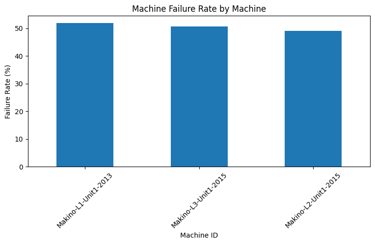

```python
machine_failure_rate["Machine_Failure"].plot(
    kind="bar",
    figsize=(9, 4)
)

plt.title("Machine Failure Rate by Machine")
plt.ylabel("Failure Rate (%)")
plt.xlabel("Machine ID")
plt.xticks(rotation=45)
plt.show()
```

### Interpretation

The machine-level comparison shows that failure rates are very similar across all three machines. Makino-L1-Unit1-2013 has the highest failure rate at approximately 51.9%, followed by Makino-L3-Unit1-2015 at 50.7% and Makino-L2-Unit1-2015 at 49.0%.

The differences are relatively small (around 3 percentage points), suggesting that machine identity alone is not a strong predictor of downtime. This result indicates that operational factors such as hydraulic pressure, temperature and torque are likely to have a greater influence on machine failure than the specific machine being used.

### Business Question 3: Do hydraulic pressure levels differ between failure and non-failure conditions?

#### Why is this important?

Hydraulic pressure is a key operating parameter in CNC machines. Understanding how pressure levels differ between failure and non-failure conditions can help maintenance teams identify early warning signs of downtime.

```python
clean_df.groupby("Downtime")["Hydraulic_Pressure(bar)"].describe()
```

| Downtime | count | mean | std | min | 25% | 50% | 75% | max |
| --- | --- | --- | --- | --- | --- | --- | --- | --- |
| Machine_Failure | 1265.0 | 84.769987 | 26.333125 | 50.140000 | 64.810000 | 80.130000 | 94.290000 | 191.0000 |
| No_Machine_Failure | 1235.0 | 118.414753 | 23.814654 | -14.326454 | 100.539942 | 120.014911 | 136.093119 | 179.8861 |

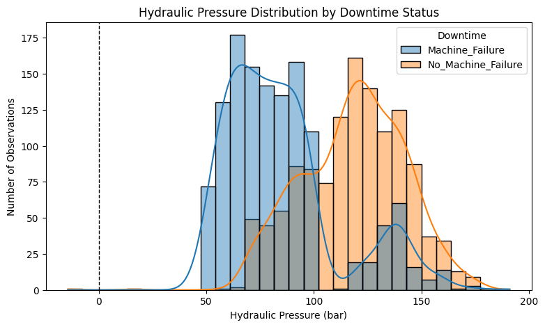

```python
plt.figure(figsize=(9, 5))

sns.histplot(
    data=clean_df,
    x="Hydraulic_Pressure(bar)",
    hue="Downtime",
    kde=True,
    bins=30,
    alpha=0.45
)

plt.axvline(0, color="black", linestyle="--", linewidth=1)
plt.title("Hydraulic Pressure Distribution by Downtime Status")
plt.xlabel("Hydraulic Pressure (bar)")
plt.ylabel("Number of Observations")
plt.show()
```

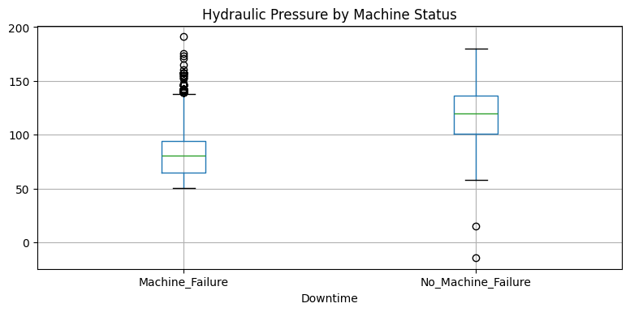

```python
clean_df.boxplot(
    column="Hydraulic_Pressure(bar)",
    by="Downtime",
    figsize=(9,4)
)

plt.title("Hydraulic Pressure by Machine Status")
plt.suptitle("")
plt.show()
```

#### Interpretation

Hydraulic pressure shows a clear difference between failure and non-failure conditions. Machines with failures generally operate at lower hydraulic pressure levels than machines without failures.

The distribution plot also makes the negative-pressure anomaly visible. Because the sensitivity check showed that this single value changes the non-failure mean by only about 0.11 bar, the main conclusion remains the same, but the value should still be treated as a data-quality issue rather than a normal operating reading.

This suggests that hydraulic pressure is one of the most useful indicators of machine health in this dataset. Maintenance teams should monitor low hydraulic pressure values closely, because pressure drops may increase the risk of unexpected downtime.

### Business Question 4: How does spindle speed behave during machine failures?

#### Why is this important?

Spindle speed directly affects machine performance. Examining spindle speed during failure events may help identify operating conditions associated with increased downtime risk.

```python
spindle_speed_summary = clean_df.groupby("Downtime")["Spindle_Speed(RPM)"].describe()

spindle_speed_summary
```

| Downtime | count | mean | std | min | 25% | 50% | 75% | max |
| --- | --- | --- | --- | --- | --- | --- | --- | --- |
| Machine_Failure | 1265.0 | 21319.361265 | 4123.213322 | 0.0 | 18461.0 | 19964.0 | 25528.0 | 27957.0 |
| No_Machine_Failure | 1235.0 | 19204.182186 | 3210.437632 | 13272.0 | 16198.0 | 20185.0 | 21667.0 | 27882.0 |

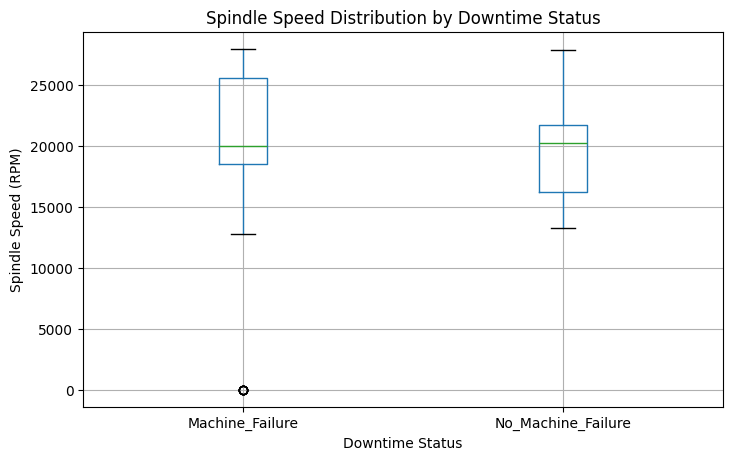

```python
clean_df.boxplot(
    column="Spindle_Speed(RPM)",
    by="Downtime",
    figsize=(8, 5)
)

plt.title("Spindle Speed Distribution by Downtime Status")
plt.suptitle("")
plt.ylabel("Spindle Speed (RPM)")
plt.xlabel("Downtime Status")
plt.show()
```

#### Interpretation

Spindle speed differs between the two machine states. The average spindle speed during machine failures is about 21,319 RPM, while the average spindle speed during normal operation is about 19,204 RPM.

This indicates that higher spindle speed is associated with machine failure conditions in this dataset. From a business perspective, machines operating at unusually high spindle speed should be monitored closely, especially when this occurs together with other abnormal sensor readings.

### Business Question 5: Which operating conditions differ most during machine failures?

#### Why is this important?

Comparing failure and non-failure conditions helps identify which operating measures change most when downtime occurs, instead of only describing failure cases in isolation.

```python
condition_comparison = clean_df.groupby("Downtime")[numeric_columns].mean().T

condition_comparison["Failure_Difference"] = (
    condition_comparison["Machine_Failure"]
    - condition_comparison["No_Machine_Failure"]
)

condition_comparison.reindex(
    condition_comparison["Failure_Difference"].abs().sort_values(ascending=False).index
).head(10)
```

| Downtime | Machine_Failure | No_Machine_Failure | Failure_Difference |
| --- | --- | --- | --- |
| Spindle_Speed(RPM) | 21319.361265 | 19204.182186 | 2115.179079 |
| Hydraulic_Pressure(bar) | 84.769987 | 118.414753 | -33.644766 |
| Torque(Nm) | 22.774421 | 27.745299 | -4.970878 |
| Coolant_Temperature | 19.983083 | 17.127773 | 2.855310 |
| Cutting(kN) | 3.055976 | 2.502470 | 0.553507 |
| Voltage(volts) | 349.258498 | 348.728745 | 0.529753 |
| Coolant_Pressure(bar) | 5.114900 | 4.775031 | 0.339870 |
| Spindle_Bearing_Temperature(C) | 34.991542 | 35.137814 | -0.146272 |
| Hydraulic_Oil_Temperature(C) | 47.571858 | 47.666964 | -0.095106 |
| Tool_Vibration(um) | 25.374898 | 25.450336 | -0.075438 |

#### Interpretation

The comparison shows which average operating values differ most between failure and non-failure records. Spindle speed and hydraulic pressure stand out: failures occur with higher average spindle speed and lower average hydraulic pressure.

This strengthens the earlier results because it compares both machine states directly. Maintenance teams should treat large shifts in these variables as stronger warning signs than variables with small average differences.

### Business Question 6: Which variables are most strongly correlated with machine failure?

#### Why is this important?

Understanding relationships between sensor measurements and failures helps identify the most influential operational factors.

```python
correlation = clean_df[numeric_columns].corr()
correlation_with_failure = clean_df[
    numeric_columns.tolist() + ["Failure_Flag"]
].corr()["Failure_Flag"]

correlation_with_failure = correlation_with_failure.drop("Failure_Flag").sort_values(
    ascending=False
)

correlation_with_failure
```

```
Cutting(kN)                       0.449461
Spindle_Speed(RPM)                0.274874
Coolant_Pressure(bar)             0.171058
Coolant_Temperature               0.167275
Air_System_Pressure(bar)          0.009175
Voltage(volts)                    0.005845
Tool_Vibration(um)               -0.005873
Hydraulic_Oil_Temperature(C)     -0.012660
Spindle_Vibration(um)            -0.016623
Spindle_Bearing_Temperature(C)   -0.019456
Torque(Nm)                       -0.406638
Hydraulic_Pressure(bar)          -0.556550
Name: Failure_Flag, dtype: float64
```

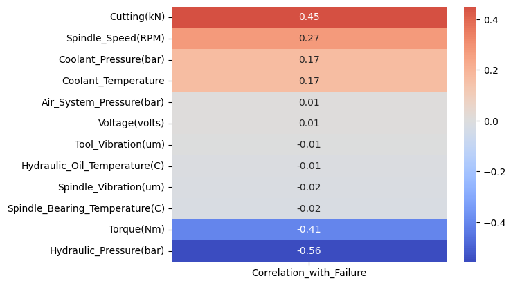

```python
sns.heatmap(
    correlation_with_failure.to_frame("Correlation_with_Failure"),
    annot=True,
    fmt=".2f",
    cmap="coolwarm",
    center=0
)
```

#### Interpretation

The correlation analysis shows that hydraulic pressure has the strongest relationship with machine failure status in absolute terms. The relationship is negative, meaning that lower hydraulic pressure is associated with a higher probability of failure. Cutting force and spindle speed also show meaningful positive relationships with failure status but hydraulic pressure is the strongest indicator.

This does not prove that low hydraulic pressure directly causes failures. However, it gives a clear business recommendation: hydraulic pressure should be one of the first variables monitored in any preventive maintenance dashboard.

### Business Question 7: Which month experienced the highest machine failure rate?

#### Why is this important?

Analysing failure rates over time helps determine whether machine failures follow any monthly pattern that could support maintenance planning.

```python
clean_df["Month"] = clean_df["Date"].dt.month

monthly_failure = pd.crosstab(
    clean_df["Month"],
    clean_df["Downtime"],
    normalize="index"
) * 100

month_counts = clean_df["Month"].value_counts()

reliable_months = month_counts[
    month_counts >= 30
].index

monthly_failure_filtered = monthly_failure.loc[
    monthly_failure.index.isin(reliable_months)
]

monthly_failure_filtered
```

| Downtime Month | Machine_Failure | No_Machine_Failure |
| --- | --- | --- |
| 1 | 48.876404 | 51.123596 |
| 2 | 49.581240 | 50.418760 |
| 3 | 50.858779 | 49.141221 |
| 4 | 53.130930 | 46.869070 |
| 5 | 43.103448 | 56.896552 |

```python
clean_df["Month"].value_counts().sort_index()
```

```
Month
1      178
2      597
3     1048
4      527
5      116
6        8
7        1
11       1
12      24
Name: count, dtype: int64
```

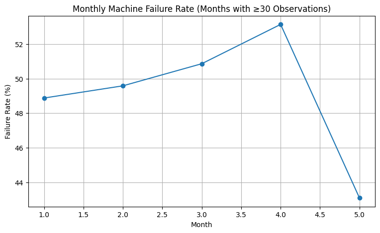

```python
monthly_failure_filtered["Machine_Failure"].plot(kind="line", marker="o", figsize=(9, 5))
plt.title("Monthly Machine Failure Rate (Months with ≥30 Observations)")
plt.ylabel("Failure Rate (%)")
plt.xlabel("Month")
plt.grid(True)
plt.show()
```

#### Interpretation

After excluding months with fewer than 30 observations, the monthly failure rates remain relatively stable. The reliable months are January to May, with failure rates between about 43% and 54%. June, July, November and December were not used for the main interpretation because their sample sizes are below the 30-record threshold.

This means the dataset does not provide strong evidence of a monthly pattern within the available January-May window. However, it is not enough to rule out true seasonality, because the data does not contain a balanced full year of observations. Maintenance planning should therefore focus more on machine operating conditions than on calendar month unless more complete time coverage becomes available.

### Business Question 8: Which combination of operating conditions creates the highest failure risk?

#### Why is this important?

Machine failures are often influenced by multiple operating conditions. Examining pressure and torque together helps identify combinations associated with higher failure risk.

```python
clean_df["Pressure_Group"] = pd.cut(
    clean_df["Hydraulic_Pressure(bar)"],
    bins=5
)

clean_df["Torque_Group"] = pd.cut(
    clean_df["Torque(Nm)"],
    bins=5
)

risk_matrix = clean_df.pivot_table(
    values="Failure_Flag",
    index="Pressure_Group",
    columns="Torque_Group",
    aggfunc="mean"
) * 100

risk_counts = clean_df.pivot_table(
    values="Failure_Flag",
    index="Pressure_Group",
    columns="Torque_Group",
    aggfunc="count"
)

risk_matrix
```

| Torque_Group Pressure_Group | (-0.0556, 11.11] | (11.11, 22.221] | (22.221, 33.331] | (33.331, 44.442] | (44.442, 55.552] |
| --- | --- | --- | --- | --- | --- |
| (-14.532, 26.739] | NaN | NaN | 0.000000 | 0.0 | NaN |
| (26.739, 67.804] | NaN | 100.000000 | 98.909091 | 100.0 | NaN |
| (67.804, 108.869] | 0.0 | 68.769716 | 70.962963 | 3.0 | NaN |
| (108.869, 149.935] | 100.0 | 34.090909 | 15.935335 | 0.0 | 0.0 |
| (149.935, 191.0] | NaN | 20.000000 | 29.230769 | 0.0 | NaN |

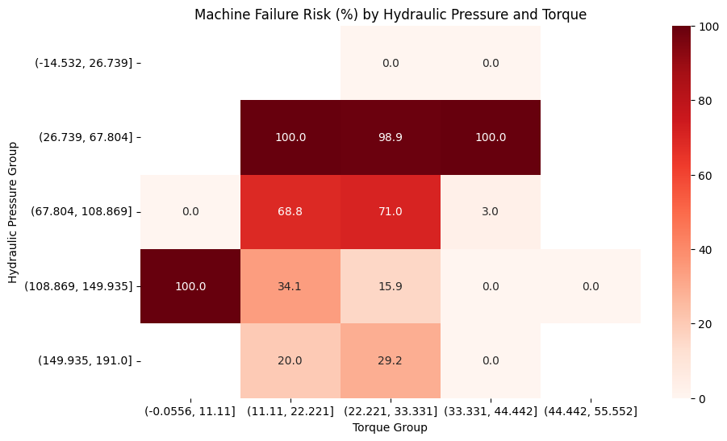

| Torque_Group Pressure_Group | (-0.0556, 11.11] | (11.11, 22.221] | (22.221, 33.331] | (33.331, 44.442] | (44.442, 55.552] |
| --- | --- | --- | --- | --- | --- |
| (-14.532, 26.739] | NaN | NaN | 1.0 | 1.0 | NaN |
| (26.739, 67.804] | NaN | 105.0 | 275.0 | 2.0 | NaN |
| (67.804, 108.869] | 1.0 | 317.0 | 675.0 | 100.0 | NaN |
| (108.869, 149.935] | 1.0 | 264.0 | 433.0 | 204.0 | 1.0 |
| (149.935, 191.0] | NaN | 35.0 | 65.0 | 20.0 | NaN |

```python
plt.figure(figsize=(10, 6))

sns.heatmap(
    risk_matrix,
    annot=True,
    fmt=".1f",
    cmap="Reds"
)

plt.title("Machine Failure Risk (%) by Hydraulic Pressure and Torque")
plt.xlabel("Torque Group")
plt.ylabel("Hydraulic Pressure Group")
plt.show()

risk_counts
```

#### Interpretation

The heatmap suggests that failure risk changes across hydraulic-pressure and torque combinations. The highest rates appear in lower hydraulic-pressure bands, supporting the earlier finding that low pressure is linked with downtime.

However, percentage risk can be inflated when a bin contains few observations. For example, the (108.869, 149.935] pressure band combined with the (-0.0556, 11.11] torque band shows 100% failure risk, but it contains only 1 observation. The risk_counts table should therefore be checked alongside the heatmap before treating any 100% cell as a reliable operational rule.

## 8. Final Discussion

This analysis used Python, Pandas and visualisation techniques to examine downtime patterns in CNC machine data. Grouped summaries, crosstabs, correlations, distribution plots, time analysis and a pressure-torque risk matrix were used to answer the business questions.

The strongest pattern is that machine failures are associated with lower hydraulic pressure and higher spindle speed. Vibration measures showed smaller differences, so they appear less useful as standalone indicators in this dataset.

The analysis has limitations. The dataset contains 2,500 records from three machines and does not include maintenance history, operators or production load. It also contains one physically impossible hydraulic-pressure value, which was retained but tested for sensitivity. The monthly analysis is limited because the reliable observations cover mainly January to May rather than a balanced full year, and some risk-matrix groups contain very few observations. Results should therefore be treated as operational patterns rather than proof of causation.

For the business, the main action is to monitor hydraulic pressure and spindle speed more closely and prioritise inspection when machines enter higher-risk pressure and torque ranges.

## 9. Conclusion

This project identified operating factors associated with machine downtime in a manufacturing setting.

Hydraulic pressure was the clearest indicator in the dataset: lower pressure levels were linked with machine failures, while higher spindle speed also appeared during downtime events. The negative hydraulic-pressure anomaly was reported and tested, and it did not materially change the pressure comparison.

The available monthly data did not show a strong pattern across the reliable January-May window, but the dataset is not complete enough to make a broad seasonal conclusion. The pressure-torque matrix added useful context by showing that combined operating conditions can reveal higher-risk areas, although small cell counts should be considered when interpreting extreme percentages.

Overall, the analysis supports practical maintenance planning by highlighting hydraulic pressure and spindle speed as priority variables for monitoring and preventive action.

## 10. References

Kaggle (2024) *Optimization of Machine Downtime Dataset*. Available at: https://www.kaggle.com/datasets/srinivasanusuri/optimization-of-machine-downtime (Accessed: June 2026).

McKinney, W. (2022) *Python for Data Analysis*. 3rd edn. Sebastopol, CA: O'Reilly Media.

Pandas (2026) *Pandas Documentation*. Available at: https://pandas.pydata.org/ (Accessed: June 2026).

Matplotlib (2026) *Matplotlib Documentation*. Available at: https://matplotlib.org/ (Accessed: June 2026).

Seaborn (2026) *Seaborn Documentation*. Available at: https://seaborn.pydata.org/ (Accessed: June 2026).